# Presentation of final project

04 December 2014

## Research Question

**What impact does decentralization have on the provision of health-related services in Benin?**

[figure not shown]

## Description of Benin

- GDP per capita: USD 804.67 in 2013
- GDP growth: 5.6% in 2013
- Population: 10.32 million habitants
- Human Development Index 2014: 165 out of 187 countries

## Why Benin?

- Decentralization and devolution: at the center of national policy for the past decade as a mechanism for poverty alleviation
- Decentralization -> huge transformation of the political and administrative organization
- Legal provisions have transfered large part of health provision competencies to subnational entities

## Theoretical background

Proponents of decentralization share the view that local governments are the major vehicles for specific poverty alleviation policies.

**Economic Theory**

- decision-making should occur at the lowest level of government –> allocation efficiency (Shah and Mundial 1994)
- local government has an informational advantage (Oates 1972)
- decentralization –> greater participation of nearby communities –> accountability of policymakers (Crook and Manor 1998) (Tiebout 1956)

## Empirical Findings

**Pros**

- (Santos 2005) (Brazil): Decentralization has contributed to double the level of access to basic sanitation and enrollment in elementary schools between 1989 and 1996. Revenue collection increased by 48%.
- (Bardhan and Mookherjee 2000): (West Bengal): Fiscal autonomy of local governments expands the volume of service delivery
- (Faguet 2004) (Bolivia): Public investment in education, water and sanitation rose significantly
- (Bird and Rodriguez 1999) (Asia and Latin-America): Positive effect of decentralization on health, primary education and infrastructure.

**Cons**

- (Reinikka and Svensson 2004) (Uganda): Capture of decentralized school grants by local officials in Uganda.
- (Treisman 2000): (developing countries): more levels of government induce higher perceived corruption, less effective provision of public health services
- (Granado, Martinez-Vazquez, and Simatupang 2008) (Indonesia): decentralization leads to yardstick competition between local governments

## Methodology and Exploratory Data Collection

**Macroeconomic approach**

- country's health-related public expenditures (WB, WHO)
- improved sanitation facilities on a macro level

Given that health related services is highly decentralized, there might be a strong correlation between the macro-overview and the microeconomic outcome.

## Micro analysis

**Estimated Model**

\[ D_{it} = \alpha + \beta_{1}Decentralization_{it} + X'\beta_{} + e \]

**Independent variable** : Decentralization

**Dependent variables**: access to water, access to toilet facilities, water provision infrastructure,healthcare centers (hospitals)

**Explanatory variables**: population, population density, per/c consumption, public expenditure per/c, health consumption, monetary poverty index, average literacy rate for head of houshold, gini

## Micro data collection

Decentralization: Authors's calculation, based on data from Municipal Financial Accounts of Benin's municipalities (Revenues & expenditures)

Dependent & Explanatory variables: Integrated Modular Survey on Households Living Conditions (EMICoV), Demographic and Health Surveys, National Census

## Model 1: water access

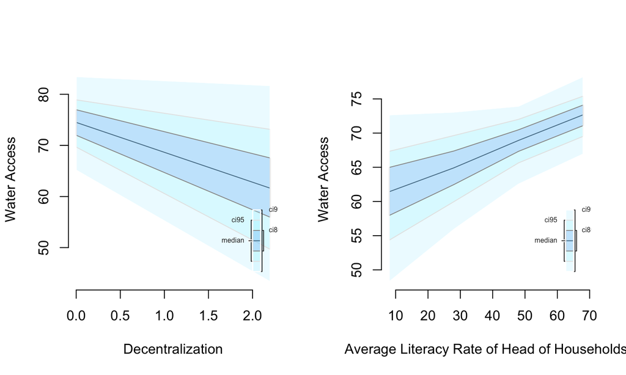

## Model 2: Impact of decentralization on access to toilet facilities

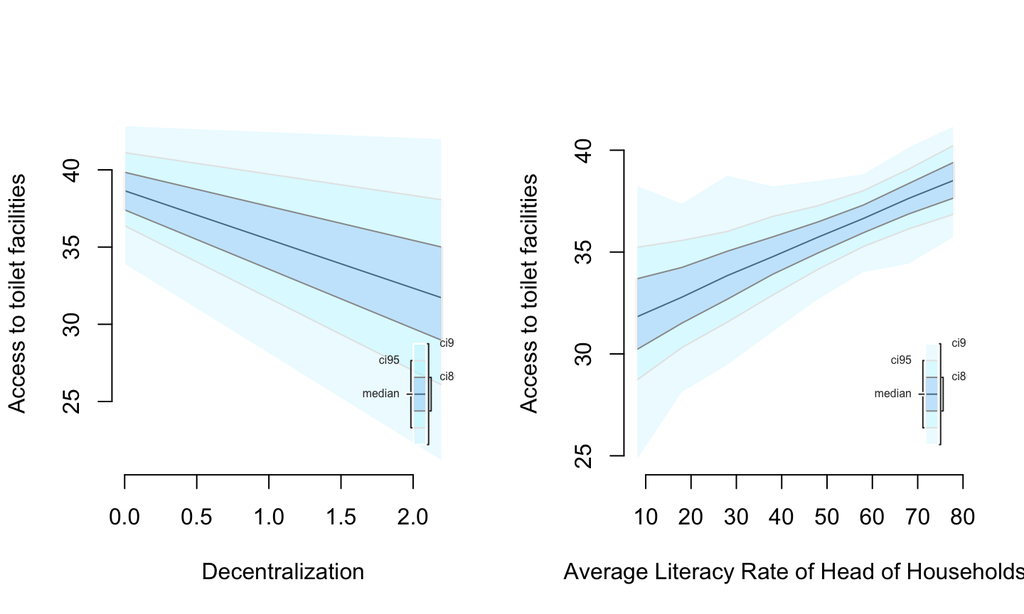

## Model 3: Impact of decentralization on connection to water facilities (pipelines)

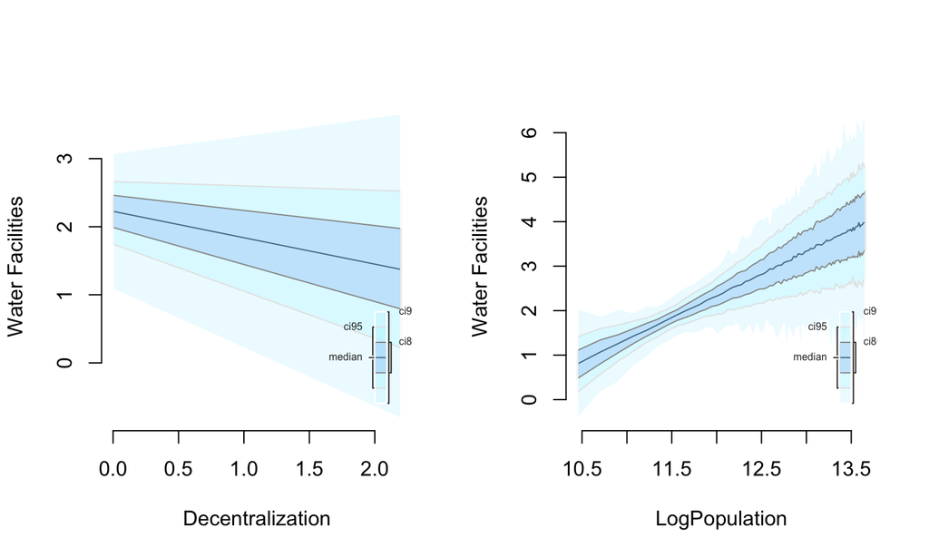

## Model 4: Impact of decentralization on access to healthcare facilities

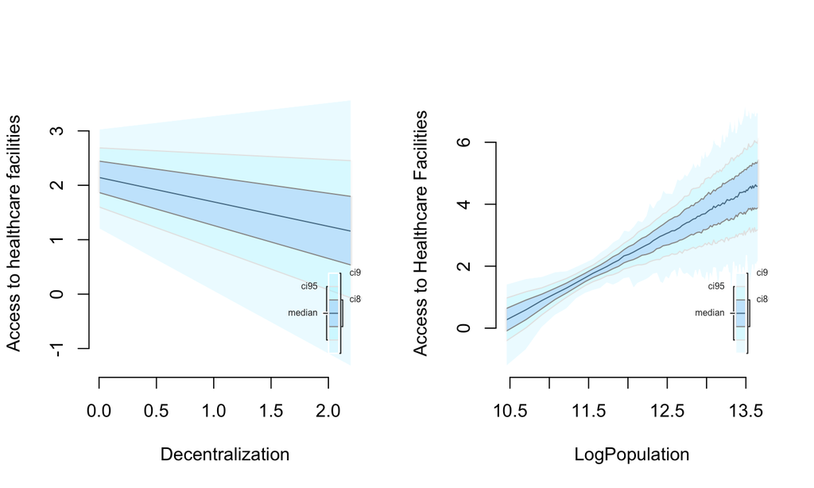

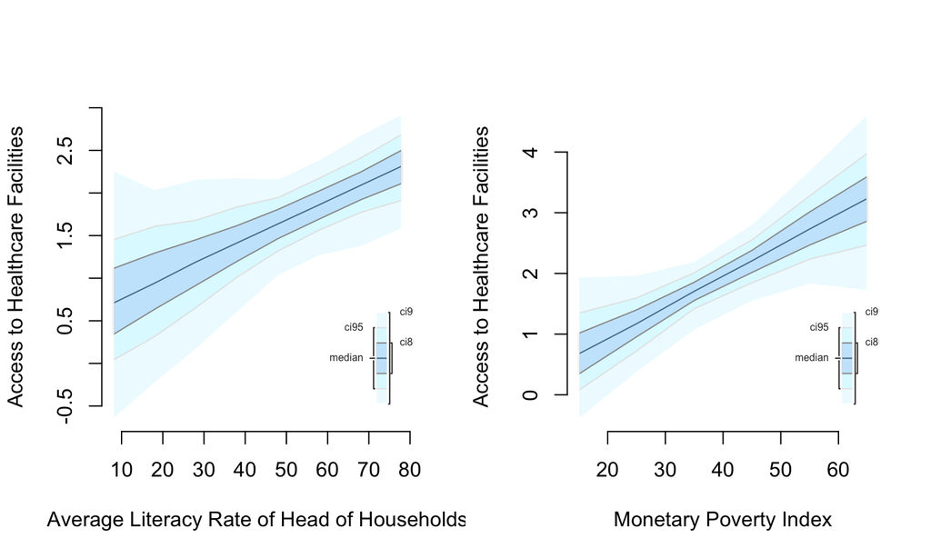

## Limitations

- Model specification
- Data limitation
- Measurement issue

[figure not shown]

## References

Bardhan, Pranab, and Dilip Mookherjee. 2000. “Capture and Governance at Local and National Levels.” *American Economic Review*, 135–39.

Bird, Richard, and Edgard R Rodriguez. 1999. “Decentralization and Poverty Alleviation. International Experience and the Case of the Philippines.” *Public Administration and Development* 19 (3): 299–319.

Crook, Richard C, and James Manor. 1998. *Democracy and Decentralisation in South Asia and West Africa: Participation, Accountability and Performance*. Cambridge University Press.

Faguet, Jean-Paul. 2004. “Does Decentralization Increase Government Responsiveness to Local Needs?: Evidence from Bolivia.” *Journal of Public Economics* 88 (3). Elsevier: 867–93.

Granado, Javier Arze del, Jorge Martinez-Vazquez, and R Renata Simatupang. 2008. “Local Government Fiscal Competition in Developing Countries: The Case of Indonesia.” *Urban Public Economics Review* 8. Universidade de Santiago de Compostela: 13–45.

Oates, Wallace E. 1972. *Fiscal Federalism*. Harcourt Brace Jovanovich.

Reinikka, Ritva, and Jakob Svensson. 2004. “Local Capture: evidence from a Central Government Transfer Program in Uganda.” *The Quarterly Journal of Economics*, 679–705.

Santos, Boaventura de Sousa. 2005. “Participatory Budgeting in Porto Alegre: toward a Redistributive Democracy.” *Democratizing Democracy: Beyond the Liberal Democratic Canon*. Verso.

Shah, Anwar, and Banco Mundial. 1994. *The Reform of Intergovernmental Fiscal Relations in Developing and Emerging Market Economies*. Vol. 23. World Bank Washington, DC.

Tiebout, Charles M. 1956. “A Pure Theory of Local Expenditures.” *The Journal of Political Economy*, 416–24.

Treisman, Daniel. 2000. “The Causes of Corruption: a Cross-National Study.” *Journal of Public Economics* 76 (3): 399–457.